# R-Script for Pre-Registration Experiment 1a: Direct evalautive ratings

Kathrin Reichmann

26 5 2021

## General Information

The second task participants will do in the experiment is a direct evaluative rating task of CSs, GSs (stimuli from the same categories) -> “type_specific” . CSs stem from one of four different categories. Categories were either paired with positive USs, or with negative USs. CSs consisted of chinese characters with two components: one component defined the category-membership (predictive component), the other varied between exemplars (non-predictive component).

Direct Evaluative Ratings are conducted on a -100 to 100 scale. Difference scores are calculated by subtracting e.g. category1 [US+] - category2 [US-] for every participant and stimulus type.

Category size (“condition”) is varied between-subjects (**one**: one exemplar per category vs. **many**: five exemplars per category).

Stimulus type (“type_discrete”) is a within-subjects variable: consists of (**CS vs. GS**) for generalization and (**predictive vs. non-predictive**) for components

Here: + Total number of participants: N = 200, + nr. obs “CS” = 2 per participant, total: 400 + nr.obs.“GS” = 6, total: 1200 *-> because participants rated 3 GSs for every category. Reduce this to 1 GS?* + nr. observations “predictive component” = 2, total: 400

## (1) Testing H1: Generalization

### Hypothesis 1:

Generalization towards novel stimuli is wider in the “many” condition than in the “one” condition.

Dummy Coded: Stimulus Type (0 - CS, 1 - GS) and Condition (0 - One, 1 - Many) Subjects N = 200, nr. of total observations: 1600 (400 for CSs, 1200 for GSs)

(1a) *non-significant fixed effect of condition*

-> no effect of condition on difference scores for **CSs**

(1b) *Significant fixed effect for cross-level interaction stimulus type x condition.*

-> effect of condition on difference scores for **GSs** : higher difference scores in the “many” condition than in the “one” condition

### Plot raw data:

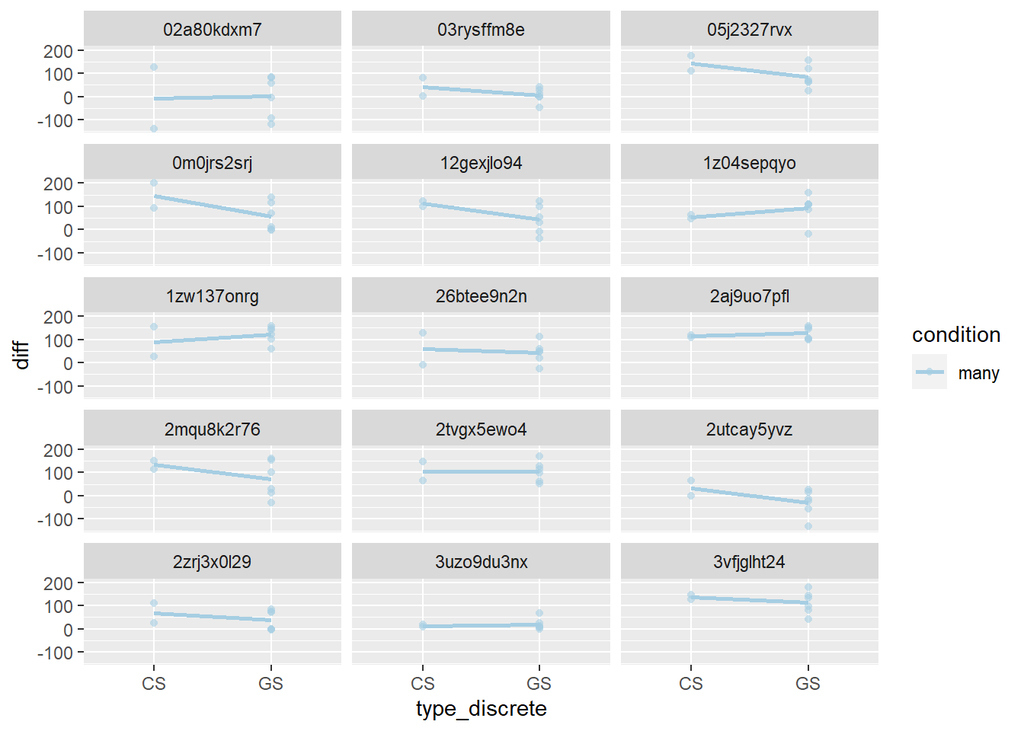

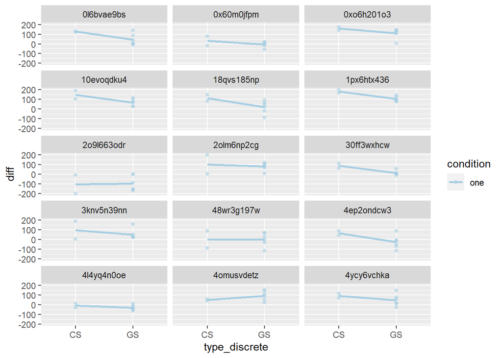

```
##   condition type_discrete     diff       se
## 1       one            CS 64.91089 5.529529
## 2      many            CS 64.16162 5.021323
## 3       one            GS 24.61056 2.848193
## 4      many            GS 46.77273 2.739109
```

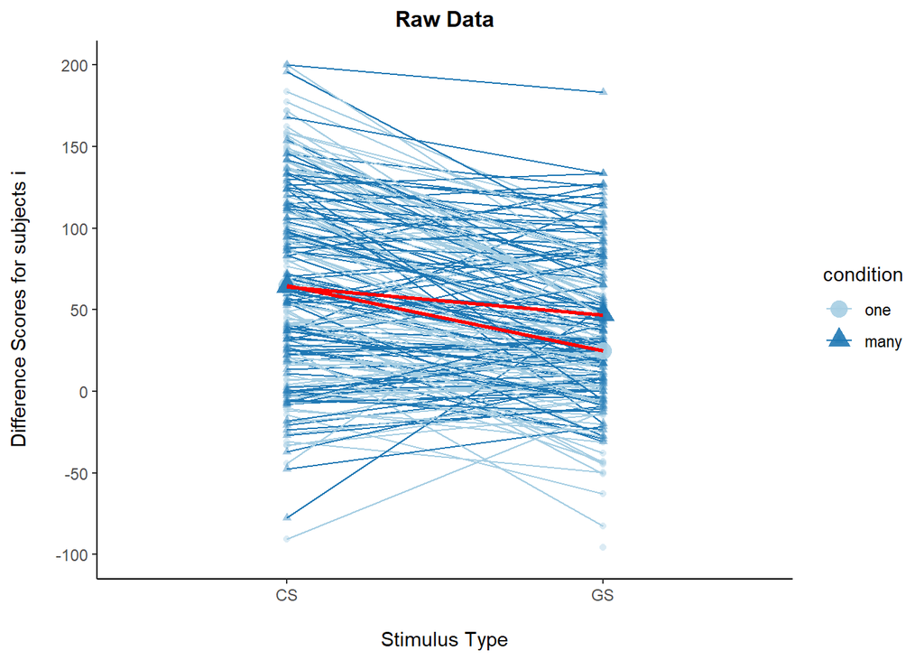

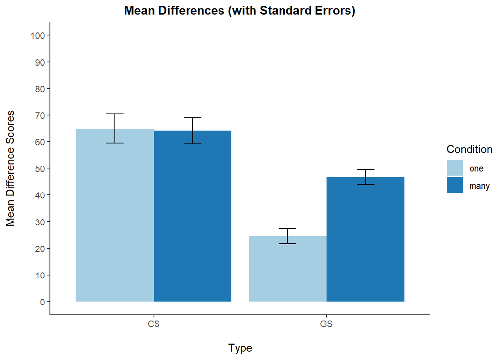

### Model 1: random intercept, fixed effect of stimulus type

```r
##### random intercept model with fixed effect of stimulus type
model1 <- lmer(diff ~ type_discrete + (1|subject), data = HLM, REML = FALSE)
summary(model1)
```

```
## Linear mixed model fit by maximum likelihood  ['lmerMod']
## Formula: diff ~ type_discrete + (1 | subject)
##    Data: HLM
##
##      AIC      BIC   logLik deviance df.resid
##  17860.0  17881.5  -8926.0  17852.0     1596
##
## Scaled residuals:
##     Min      1Q  Median      3Q     Max
## -3.6518 -0.5803  0.0198  0.6695  2.8826
##
## Random effects:
##  Groups   Name        Variance Std.Dev.
##  subject  (Intercept) 1626     40.32
##  Residual             3367     58.03
## Number of obs: 1600, groups:  subject, 200
##
## Fixed effects:
##                 Estimate Std. Error t value
## (Intercept)       64.540      4.068  15.866
## type_discreteGS  -28.959      3.350  -8.644
##
## Correlation of Fixed Effects:
##             (Intr)
## typ_dscrtGS -0.618
```

```
##       diff type_discrete
## 1 64.54000            CS
## 2 35.58083            GS
```

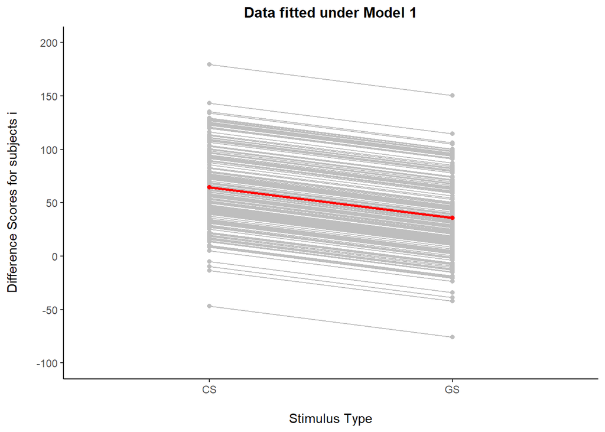

### Model 2: + random slope

```
##       diff type_discrete
## 1 64.54000            CS
## 2 35.58083            GS
```

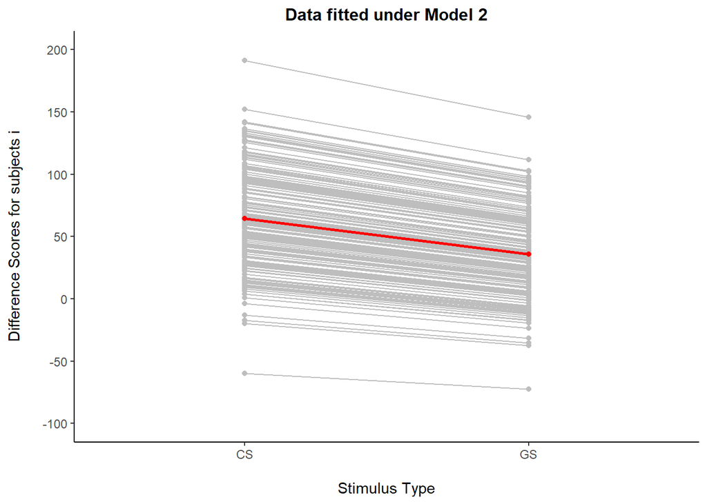